# Homework 05

Set a random seed before each simulation question and report it. You may use standard packages unless a question asks you to write the calculation yourself. Use equal neighbor weights throughout. Here $p$ counts the covariates used to measure distance; do not add an intercept column to a KNN predictor matrix. R and Python use different random-number generators, so their exact simulation results need not agree.

## Question 1: Estimate the bias and variance of KNN

In our previous homework, we used repeated simulations to study the behavior of linear regression estimators. We will now use the same idea for KNN. Consider the regression model

$$Y_i=f(\mathbf X_i)+\epsilon_i,
\qquad
f(\mathbf x)=0.5x_1+\sin(x_2)-0.3x_3^2,$$

where the three covariates are independent standard normal variables and $\epsilon_i\sim\mathcal N(0,0.1^2)$ independently of the covariates and other observations. Generate $n=400$ training observations. Our goal is to estimate the mean response at

$$\mathbf x_0=(0.5,0.7,1)^{\mathsf T}.$$

Use Euclidean distance and consider $k=1,3,5,\ldots,29$.

1. Calculate $f(\mathbf x_0)$. Generate one training dataset and obtain the KNN prediction at $\mathbf x_0$ for each value of $k$.

   **Show the workflow**

   ```r
   # Calculate f(x0)
   x0 <- matrix(c(0.5, 0.7, 1), nrow = 1)
   colnames(x0) <- paste0("X", 1:3)
   f_x0 <- 0.5 * x0[1] + sin(x0[2]) - 0.3 * x0[3]^2
   ```

   $$f(x_0) = 0.5(0.5) + sin(0.7) - 0.3(1)^2 \approx 0.5942177$$

   **Show the workflow**

   ```r
   set.seed(43201)

   # Generate 400 training observations
   n <- 400
   p <- 3
   e <- rnorm(n, mean = 0, sd = 0.1)
   k <- seq(from = 1, to = 29, by = 2)

   X <- matrix(rnorm(n * p), nrow = n, ncol = p)
   colnames(X) <- paste0("X", 1:p)
   Y_train <- 0.5 * X[,1] + sin(X[,2]) - 0.3 * X[,3]^2 + e

   # KNN regression using kknn package
   library(kknn)

   # Initialize KNN prediction
   KNN_pred <- vector(mode = "numeric", length = length(k))

   for (i in seq_along(k)){

     # Fit KNN for each k
     knn_fit <- kknn(Y_train ~ .,
                     train = data.frame(X, Y_train),
                     test = data.frame(x0),
                     k = k[i],
                     kernel = "rectangular")
     KNN_pred[i] <- knn_fit$fitted.values
   }

   data.frame(k = k, prediction = KNN_pred, truth = f_x0)
   ```

   ```
       k prediction     truth
   1   1  0.7022655 0.5942177
   2   3  0.7369335 0.5942177
   3   5  0.5941112 0.5942177
   4   7  0.4143961 0.5942177
   5   9  0.2997807 0.5942177
   6  11  0.3041238 0.5942177
   7  13  0.3513152 0.5942177
   8  15  0.3157201 0.5942177
   9  17  0.3725657 0.5942177
   10 19  0.3694252 0.5942177
   11 21  0.3521679 0.5942177
   12 23  0.3628800 0.5942177
   13 25  0.3454246 0.5942177
   14 27  0.3660580 0.5942177
   15 29  0.3767993 0.5942177
   ```

2. Independently repeat the generation of the training covariates and responses 200 times. Within each repetition, use the same training data for every value of $k$. Store the predictions in a matrix with 200 rows and one column for each value of $k$. Use this matrix to estimate the bias, variance, and mean squared error of the estimated mean response. Use divisor 200 when calculating the empirical variance, and verify numerically that

$$\text{mean squared error}
=\text{squared bias}+\text{variance}.$$

Plot squared bias, variance, and mean squared error against $k$ in one figure. Explain the pattern and compare it with the bias-variance trade-off for ridge regression or lasso.

**Show the workflow**

```r
set.seed(43211)
sim <- 200
KNN_pred2 <- matrix(NA_real_, nrow = sim, ncol = length(k))

for (i in seq_len(sim)) {
  X <- matrix(rnorm(n * p), nrow = n, ncol = p)
  colnames(X) <- paste0("X", 1:p)
  e <- rnorm(n, mean = 0, sd = 0.1)
  Y_train <- 0.5 * X[, 1] + sin(X[, 2]) - 0.3 * X[, 3]^2 + e

  for (j in seq_along(k)) {
    knn_fit <- kknn(Y_train ~ ., train = data.frame(X, Y_train),
                    test = data.frame(x0), k = k[j], kernel = "rectangular")
    KNN_pred2[i, j] <- knn_fit$fitted.values
  }
}

prediction_mean <- colMeans(KNN_pred2)
squared_bias <- (prediction_mean - f_x0)^2
variance <- colMeans(sweep(KNN_pred2, 2, prediction_mean, "-")^2)
MSE_decomposed <- squared_bias + variance
MSE_direct <- colMeans((KNN_pred2 - f_x0)^2)

data.frame(k = k, squared_bias = squared_bias, variance = variance,
           MSE_direct = MSE_direct,
           difference = MSE_direct - MSE_decomposed)
```

```
    k squared_bias    variance MSE_direct    difference
1   1 0.0004744369 0.034257053 0.03473149  0.000000e+00
2   3 0.0014851253 0.020263252 0.02174838  0.000000e+00
3   5 0.0012193138 0.014279814 0.01549913 -3.469447e-18
4   7 0.0016508339 0.012958274 0.01460911  1.734723e-18
5   9 0.0023625892 0.011282401 0.01364499 -5.204170e-18
6  11 0.0028905060 0.010557876 0.01344838  1.734723e-18
7  13 0.0039524544 0.009650770 0.01360322  1.734723e-18
8  15 0.0052773619 0.009574408 0.01485177 -5.204170e-18
9  17 0.0061000736 0.008798612 0.01489869 -8.673617e-18
10 19 0.0072849560 0.008639658 0.01592461  3.469447e-18
11 21 0.0083402556 0.008483835 0.01682409 -3.469447e-18
12 23 0.0094293720 0.007676491 0.01710586  0.000000e+00
13 25 0.0115431636 0.007930409 0.01947357  3.469447e-18
14 27 0.0118868768 0.007059542 0.01894642  0.000000e+00
15 29 0.0131190666 0.006705355 0.01982442 -3.469447e-18
```

**Show the workflow**

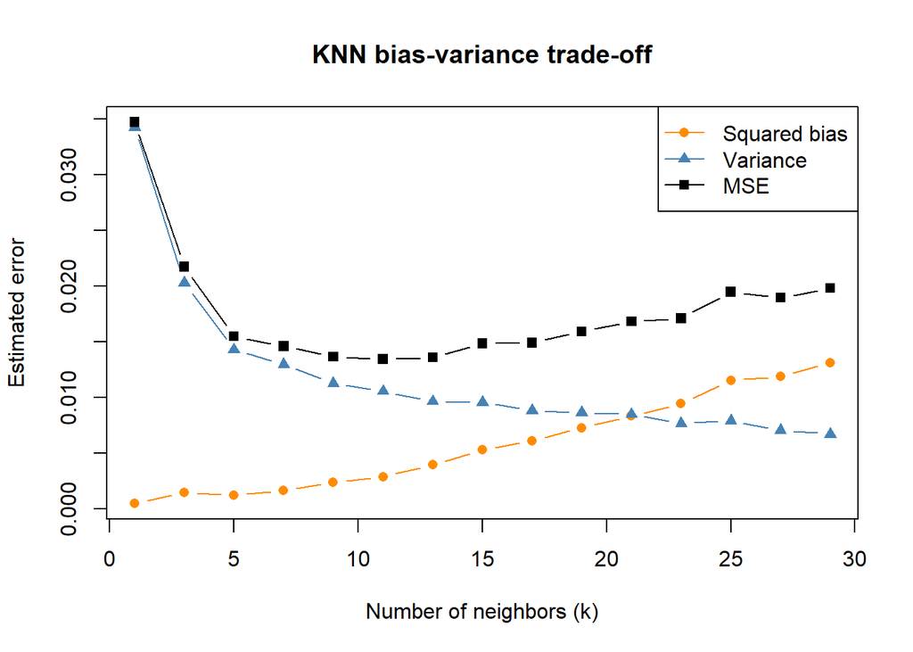

```r
matplot(k, cbind(squared_bias, variance, MSE_direct), type = "b",
        pch = c(16, 17, 15), lty = 1,
        col = c("darkorange", "steelblue", "black"),
        xlab = "Number of neighbors (k)", ylab = "Estimated error",
        main = "KNN bias-variance trade-off")
legend("topright", c("Squared bias", "Variance", "MSE"),
       col = c("darkorange", "steelblue", "black"),
       pch = c(16, 17, 15), lty = 1)
```

As $k$ increases, KNN averages more observations, so its predictions are usually less sensitive to a particular training sample and variance tends to fall. The larger neighborhood also includes observations farther from the target, which can make the estimate less locally accurate and increase bias. MSE is the sum of squared bias and variance, so it may be smallest at an intermediate $k$. Ridge and lasso have a similar trade-off: stronger penalties reduce coefficient flexibility and often variance, but can increase bias by shrinking slopes. KNN controls flexibility through neighborhood size; ridge and lasso control it through coefficient penalties.

## Question 2: Compare KNN with lasso

Use the response model from Question 1, including the noise standard deviation $0.1$, but generate $p=30$ covariates. The response still depends only on the first three. Consider these two settings:

- **Setting 1:** all 30 covariates are independent standard normal variables.
- **Setting 2:** the covariates have a multivariate normal distribution with mean zero and covariance matrix $\boldsymbol\Sigma$, where

  $$\Sigma_{jj}=1,
  \qquad
  \Sigma_{jl}=0.8\quad\text{for }j\ne l.$$

In each setting, generate 400 training observations and 1,000 independent test observations. Fit 5NN using Euclidean distance on the supplied covariate scale. All covariates already have population variance one.

For lasso, use a linear model containing the 30 covariates and a separately fitted, unpenalized intercept. Follow the Week 4 objective,

$$L_\lambda(\boldsymbol\beta)
=\frac{1}{2n}\left\lVert
\widetilde{\mathbf y}-\mathbf X\boldsymbol\beta
\right\rVert_2^2
+\lambda\lVert\boldsymbol\beta\rVert_1,$$

where $\mathbf X\in\mathbb R^{n\times30}$ contains the centered and standardized covariates and $\widetilde{\mathbf y}$ is the centered training response. Select the penalty by ten-fold cross-validation over 41 logarithmically spaced values from $10^{-4}$ to $1$. Estimate all means and scales using only the training portion of each fold, with divisor equal to that portion’s sample size. After selecting the penalty, refit on all training observations and apply the fitted transformations unchanged to the test observations. Do not add nonlinear terms to the lasso model.

1. Fit both methods in each setting. Use the same training and test data for the two methods within a setting. Report their test MSE values in one table, together with the selected lasso penalty and the number of nonzero lasso slopes. You only need to generate one dataset for each setting; repeated simulations are not required.

**Show the workflow**

```r
set.seed(43202)
library(kknn)
library(glmnet)
```

**Show the workflow**

```r
n_train <- 400
n_test <- 1000
p <- 30
lambda_grid <- 10^seq(0, -4, length.out = 41)

# Generate both settings. In Setting 2, the common component induces
# population correlation 0.8 while each predictor retains variance 1.
X_train <- vector("list", 2)
X_test <- vector("list", 2)
Y_train <- vector("list", 2)
Y_test <- vector("list", 2)
for (s in 1:2) {
  if (s == 1) {
    X_train[[s]] <- matrix(rnorm(n_train * p), nrow = n_train)
    X_test[[s]] <- matrix(rnorm(n_test * p), nrow = n_test)
  } else {
    shared_train <- matrix(rnorm(n_train), nrow = n_train, ncol = p)
    shared_test <- matrix(rnorm(n_test), nrow = n_test, ncol = p)
    X_train[[s]] <- sqrt(0.8) * shared_train +
      sqrt(0.2) * matrix(rnorm(n_train * p), nrow = n_train)
    X_test[[s]] <- sqrt(0.8) * shared_test +
      sqrt(0.2) * matrix(rnorm(n_test * p), nrow = n_test)
  }
  Y_train[[s]] <- 0.5 * X_train[[s]][, 1] + sin(X_train[[s]][, 2]) -
    0.3 * X_train[[s]][, 3]^2 + rnorm(n_train, sd = 0.1)
  Y_test[[s]] <- 0.5 * X_test[[s]][, 1] + sin(X_test[[s]][, 2]) -
    0.3 * X_test[[s]][, 3]^2 + rnorm(n_test, sd = 0.1)
}

results <- data.frame(Setting = c("Independent", "Correlated"),
                      KNN_MSE = NA_real_, Lasso_MSE = NA_real_,
                      Lambda = NA_real_, Nonzero_slopes = NA_integer_)
fold_id <- sample(rep(1:10, length.out = n_train))

for (s in 1:2) {
  train_df <- as.data.frame(X_train[[s]])
  test_df <- as.data.frame(X_test[[s]])
  names(test_df) <- names(train_df)
  train_df$response <- Y_train[[s]]

  knn_fit <- kknn(response ~ ., train = train_df, test = test_df,
                  k = 5, kernel = "rectangular")
  results$KNN_MSE[s] <- mean((Y_test[[s]] - knn_fit$fitted.values)^2)

  cv_predictions <- matrix(NA_real_, nrow = n_train,
                           ncol = length(lambda_grid))
  for (fold in 1:10) {
    valid <- which(fold_id == fold)
    fit_rows <- which(fold_id != fold)
    X_fit <- X_train[[s]][fit_rows, , drop = FALSE]
    X_valid <- X_train[[s]][valid, , drop = FALSE]
    x_mean <- colMeans(X_fit)
    x_scale <- sqrt(colMeans(sweep(X_fit, 2, x_mean, "-")^2))
    X_fit_scaled <- scale(X_fit, center = x_mean, scale = x_scale)
    X_valid_scaled <- scale(X_valid, center = x_mean, scale = x_scale)
    y_mean <- mean(Y_train[[s]][fit_rows])

    cv_fit <- glmnet(X_fit_scaled, Y_train[[s]][fit_rows] - y_mean,
                     alpha = 1, lambda = lambda_grid,
                     intercept = FALSE, standardize = FALSE)
    cv_predictions[valid, ] <- predict(cv_fit, newx = X_valid_scaled,
                                       s = lambda_grid) + y_mean
  }
  cv_mse <- colMeans((cv_predictions - Y_train[[s]])^2)
  best_lambda <- lambda_grid[which.min(cv_mse)]

  x_mean <- colMeans(X_train[[s]])
  x_scale <- sqrt(colMeans(sweep(X_train[[s]], 2, x_mean, "-")^2))
  X_train_scaled <- scale(X_train[[s]], center = x_mean, scale = x_scale)
  X_test_scaled <- scale(X_test[[s]], center = x_mean, scale = x_scale)
  y_mean <- mean(Y_train[[s]])
  lasso_fit <- glmnet(X_train_scaled, Y_train[[s]] - y_mean,
                      alpha = 1, lambda = best_lambda,
                      intercept = FALSE, standardize = FALSE)
  lasso_pred <- as.vector(predict(lasso_fit, newx = X_test_scaled)) + y_mean

  results$Lasso_MSE[s] <- mean((Y_test[[s]] - lasso_pred)^2)
  results$Lambda[s] <- best_lambda
  results$Nonzero_slopes[s] <- sum(as.vector(coef(lasso_fit))[-1] != 0)
}
results
```

```
      Setting   KNN_MSE Lasso_MSE     Lambda Nonzero_slopes
1 Independent 0.5927947 0.2516592 0.03981072              5
2  Correlated 0.1658506 0.2746898 0.01584893              7
```

2. Compare the results between the two settings. Explain how correlation can change the usefulness of Euclidean neighborhoods, and why lasso does not use all covariates in the same way as KNN.
3. The response model contains $\sin(X_2)$ and $X_3^2$, but the lasso fit uses only linear terms. Explain how this difference affects the comparison. Would the results justify a general claim that correlation always helps KNN, or that one method is always better? Explain why.

**b.** Compare the test MSE values in the table. KNN uses all predictors to decide which observations are close, so correlation changes how Euclidean distance weights shared movement across predictors. Lasso instead estimates separate slopes and can shrink some to zero; with correlated predictors, variables can also act as proxies for one another. These two simulated datasets show what happened in these particular draws, not a universal effect of correlation.

**c.** Lasso uses only linear predictor terms, so it cannot fully represent the sine and squared effects in the response. KNN is not restricted to a linear form, though its accuracy depends on finding useful neighbors. Therefore, the test-error comparison reflects both the geometry of KNN neighborhoods and the linear-model restriction of lasso. One simulation per setting is not enough to claim correlation always helps KNN or that one method is always better.

## Question 3: Observed dimension and latent dimension

The lecture’s handwritten digit example shows that KNN can work with many measured covariates. We will use a simulation to investigate why the structure of those covariates matters.

Let $p=100$ be the number of observed covariates and let $m$ be the number of latent variables. For each observation, generate

$$\mathbf X_i=\mathbf A\mathbf Z_i+\boldsymbol\eta_i,
\qquad
Y_i=Z_{i1}+Z_{i2}+\epsilon_i,$$

where $\mathbf A\in\mathbb R^{100\times m}$ has independent entries from Uniform$[-2,2]$. The entries of $\mathbf Z_i\in\mathbb R^m$ and $\boldsymbol\eta_i\in\mathbb R^{100}$, and the scalar $\epsilon_i$, are independent standard normal variables, also independent of $\mathbf A$. Generate $\mathbf A$ once and use it for all training and test observations in that dataset.

Compare $m=3$ and $m=30$. In each setting, generate 200 training observations and 200 independent test observations. Fit KNN using only the 100 observed covariates in $\mathbf X$, with Euclidean distance on their generated scale. The latent variables in $\mathbf Z$ are used to generate the data but are not available to the fitted model. Consider $k=2,10,18,\ldots,82$.

1. Generate one dataset for each value of $m$. Fit KNN for every value of $k$ and calculate test MSE. Within a setting, use the same training and test observations for all values of $k$.

**Show the workflow**

```r
library(kknn)
set.seed(43203)
p <- 100
n_train <- 200
n_test <- 200
m_values <- c(3, 30)
k_values <- seq(2, 82, by = 8)
mse_one <- matrix(NA_real_, nrow = length(k_values), ncol = 2)

for (s in seq_along(m_values)) {
  m <- m_values[s]
  A <- matrix(runif(p * m, -2, 2), nrow = p, ncol = m)
  Z_train <- matrix(rnorm(n_train * m), nrow = n_train, ncol = m)
  Z_test <- matrix(rnorm(n_test * m), nrow = n_test, ncol = m)
  X_train <- Z_train %*% t(A) + matrix(rnorm(n_train * p), nrow = n_train)
  X_test <- Z_test %*% t(A) + matrix(rnorm(n_test * p), nrow = n_test)
  Y_train <- Z_train[, 1] + Z_train[, 2] + rnorm(n_train)
  Y_test <- Z_test[, 1] + Z_test[, 2] + rnorm(n_test)

  for (j in seq_along(k_values)) {
    train_df <- as.data.frame(X_train)
    test_df <- as.data.frame(X_test)
    names(test_df) <- names(train_df)
    train_df$response <- Y_train
    fit <- kknn(response ~ ., train = train_df, test = test_df,
          k = k_values[j], kernel = "rectangular")
    mse_one[j, s] <- mean((Y_test - fit$fitted.values)^2)
  }
}
data.frame(k = k_values, m3 = mse_one[, 1], m30 = mse_one[, 2])
```

```
    k       m3      m30
1   2 1.796748 2.830931
2  10 1.392138 2.081898
3  18 1.466081 2.060952
4  26 1.585057 2.086293
5  34 1.690947 2.169599
6  42 1.772496 2.198882
7  50 1.890222 2.247585
8  58 1.969719 2.273505
9  66 2.049467 2.323838
10 74 2.138548 2.338465
11 82 2.216969 2.370151
```

2. Repeat the complete experiment 50 times, generating a new $\mathbf A$ and new observations in each repetition. Plot average test MSE against $k$, with one curve for each value of $m$. These curves compare the specified choices of $k$ in a controlled simulation; they are not a cross-validation procedure for selecting a final model.

**Show the workflow**

```r
set.seed(43204)
nsim <- 50
test_mse <- array(NA_real_, dim = c(nsim, length(k_values), 2))

for (b in seq_len(nsim)) {
  for (s in seq_along(m_values)) {
    m <- m_values[s]
    A <- matrix(runif(p * m, -2, 2), nrow = p, ncol = m)
    Z_train <- matrix(rnorm(n_train * m), nrow = n_train, ncol = m)
    Z_test <- matrix(rnorm(n_test * m), nrow = n_test, ncol = m)
    X_train <- Z_train %*% t(A) + matrix(rnorm(n_train * p), nrow = n_train)
    X_test <- Z_test %*% t(A) + matrix(rnorm(n_test * p), nrow = n_test)
    Y_train <- Z_train[, 1] + Z_train[, 2] + rnorm(n_train)
    Y_test <- Z_test[, 1] + Z_test[, 2] + rnorm(n_test)

    for (j in seq_along(k_values)) {
      train_df <- as.data.frame(X_train)
      test_df <- as.data.frame(X_test)
      names(test_df) <- names(train_df)
      train_df$response <- Y_train
      fit <- kknn(response ~ ., train = train_df, test = test_df,
          k = k_values[j], kernel = "rectangular")
      test_mse[b, j, s] <- mean((Y_test - fit$fitted.values)^2)
    }
  }
}

average_mse <- apply(test_mse, c(2, 3), mean)
data.frame(k = k_values, m3 = average_mse[, 1], m30 = average_mse[, 2])
```

```
    k       m3      m30
1   2 1.724458 3.015210
2  10 1.325309 2.326626
3  18 1.344564 2.328039
4  26 1.387045 2.364970
5  34 1.441126 2.397061
6  42 1.503901 2.422397
7  50 1.561041 2.448782
8  58 1.622170 2.477396
9  66 1.681847 2.504736
10 74 1.745880 2.534602
11 82 1.809267 2.563031
```

**Show the workflow**

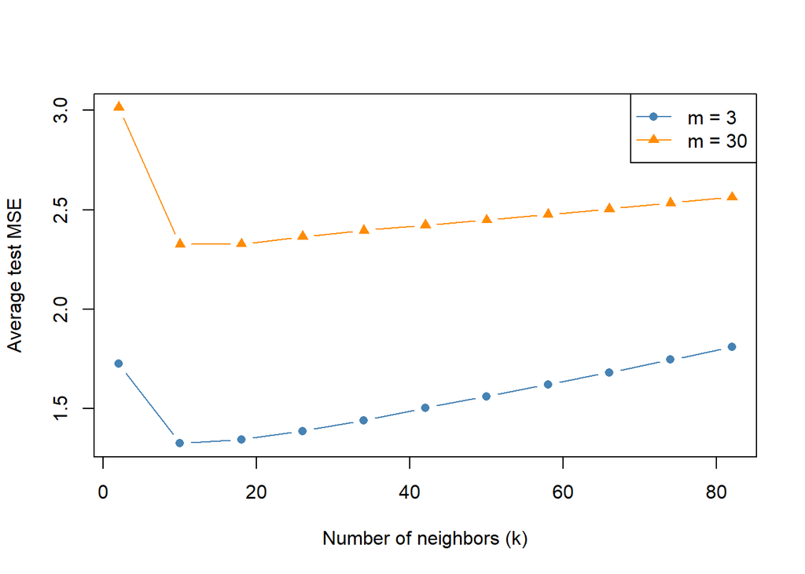

```r
matplot(k_values, average_mse, type = "b", pch = c(16, 17), lty = 1,
        col = c("steelblue", "darkorange"),
        xlab = "Number of neighbors (k)", ylab = "Average test MSE")
legend("topright", c("m = 3", "m = 30"),
       col = c("steelblue", "darkorange"), pch = c(16, 17), lty = 1)
```

3. Both settings have 100 observed covariates, and the response depends on only two latent variables. Explain why their KNN performance can still differ. What role does the noise $\boldsymbol\eta_i$ play, and why are the observed data not confined exactly to an $m$-dimensional linear space?

**c.** KNN uses all 100 observed predictors to decide which observations are close. When $m=30$, many latent variables affect the predictors even though only the first two affect the response. Those extra directions can make observations with similar responses seem far apart and make neighbors less useful. The noise $\boldsymbol\eta_i$ adds random variation to every observed predictor. Without that noise, $\mathbf A\mathbf Z_i$ lies in the column space of $\mathbf A$; adding noise moves observations away from that lower-dimensional space. In the 50-repetition experiment, the $m=3$ setting has lower average test MSE overall, although the curves can vary across values of $k$.

## Question 4: Classify handwritten digits

Use `zip.train` and `zip.test` from the R package `ElemStatLearn`, as in the lecture. The package has been retired from the active CRAN repository. If needed, install the [archived package](https://cran.r-project.org/src/contrib/Archive/ElemStatLearn/ElemStatLearn_2015.6.26.2.tar.gz) into your usual R library, then load the two datasets. Python users can use the course copies of the same [training data](https://teazrq.github.io/stat432rpy/data/knn/zip-train.csv.gz) and [test data](https://teazrq.github.io/stat432rpy/data/knn/zip-test.csv.gz). These compressed CSV files have no headers and are included in the homework ZIP under `data/knn`. Run the Python code from the folder containing `data`.

Each image has $16\times16=256$ pixel values. The first column is the digit label and the remaining columns are the pixel values. Use the first 1,000 rows of `zip.train` and the first 500 rows of `zip.test`. Use the original pixel values without standardization, and do not include the digit label in a distance calculation.

For a test image $\mathbf x_0$ and a training image $\mathbf x_i$, the two distances are

$$d_E(\mathbf x_0,\mathbf x_i)
=\sqrt{\sum_{j=1}^{256}(x_{0j}-x_{ij})^2},
\qquad
d_M(\mathbf x_0,\mathbf x_i)
=\sum_{j=1}^{256}|x_{0j}-x_{ij}|.$$

1. Write a 5NN classification function that allows either Euclidean or Manhattan distance. For each test image, calculate its distances to the training images directly, find the five nearest, and return the most frequent digit label. Break distance ties by the smaller training row number and voting ties by the smallest digit. Do not use a built-in distance or KNN function for this part.
2. Apply the classifier to all 500 test images using each distance. For each fit, report the test classification error and a $10\times10$ confusion matrix, with rows representing predicted digits and columns representing true digits. Keep all digit labels from 0 through 9 in the matrix, including any with a zero count. Which digits are most often confused with one another?
3. For Euclidean distance, display three incorrectly classified test images, together with their true and predicted labels. Comment on whether the mistakes are visually understandable. Compare the overall results of the two distance measures. Can they have similar total error while making mistakes on different images? Use your predictions to support your answer.

**Show the workflow**

```r
library(ElemStatLearn)
train_data <- zip.train[1:1000, ]
test_data <- zip.test[1:500, ]
X_train_digits <- train_data[, -1]
y_train_digits <- as.integer(train_data[, 1])
X_test_digits <- test_data[, -1]
y_test_digits <- as.integer(test_data[, 1])

knn5_manual <- function(X_train, y_train, X_test, distance = c("euclidean", "manhattan")) {
  distance <- match.arg(distance)
  predictions <- integer(nrow(X_test))
  for (i in seq_len(nrow(X_test))) {
    differences <- sweep(X_train, 2, X_test[i, ], "-")
    if (distance == "euclidean") {
      distances <- sqrt(rowSums(differences^2))
    } else {
      distances <- rowSums(abs(differences))
    }
    nearest <- order(distances, seq_along(distances))[1:5]
    votes <- tabulate(y_train[nearest] + 1L, nbins = 10)
    predictions[i] <- which.max(votes) - 1L
  }
  predictions
}

pred_euclidean <- knn5_manual(X_train_digits, y_train_digits,
                              X_test_digits, "euclidean")
pred_manhattan <- knn5_manual(X_train_digits, y_train_digits,
                              X_test_digits, "manhattan")

error_euclidean <- mean(pred_euclidean != y_test_digits)
error_manhattan <- mean(pred_manhattan != y_test_digits)
confusion_euclidean <- table(
  Predicted = factor(pred_euclidean, levels = 0:9),
  True = factor(y_test_digits, levels = 0:9))
confusion_manhattan <- table(
  Predicted = factor(pred_manhattan, levels = 0:9),
  True = factor(y_test_digits, levels = 0:9))

error_euclidean
```

```
[1] 0.122
```

**Show the workflow**

```r
confusion_euclidean
```

```
         True
Predicted   0   1   2   3   4   5   6   7   8   9
        0 118   0   7   1   0   4   2   0   2   0
        1   0  66   0   0   2   0   0   0   0   1
        2   0   0  39   1   0   0   2   0   0   1
        3   0   0   0  23   0   4   0   0   2   0
        4   0   0   1   0  27   1   1   1   0   1
        5   0   0   0   1   0  13   0   0   0   0
        6   0   2   0   0   0   1  41   0   2   0
        7   0   0   0   0   1   1   0  34   0   4
        8   0   0   3   2   0   2   0   0  37   0
        9   1   0   0   1   4   0   0   1   1  41
```

**Show the workflow**

```r
error_manhattan
```

```
[1] 0.138
```

**Show the workflow**

```r
confusion_manhattan
```

```
         True
Predicted   0   1   2   3   4   5   6   7   8   9
        0 118   0   6   1   0   5   3   0   4   0
        1   0  67   2   0   2   0   1   0   0   1
        2   0   0  35   0   0   0   2   0   0   0
        3   0   0   1  24   0   4   0   0   2   0
        4   0   0   1   1  27   1   0   1   0   1
        5   0   0   0   1   0  11   0   0   0   0
        6   0   1   0   0   0   2  40   0   2   0
        7   0   0   2   1   1   0   0  34   0   5
        8   0   0   2   0   0   3   0   0  34   0
        9   1   0   1   1   4   0   0   1   2  41
```

For this specified split, Euclidean distance gives a test error of 0.122 and Manhattan distance gives 0.138. The confusion matrices above show which digits are confused most often; both metrics make mistakes, and the particular images misclassified need not be the same.

**Show the workflow**

```
[1] "digit  6  taken"
```

```
[1] "digit  2  taken"
```

```
[1] "digit  4  taken"
```

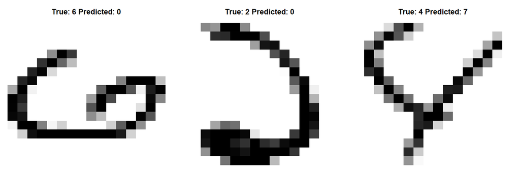

```r
wrong <- which(pred_euclidean != y_test_digits)
shown <- wrong[seq_len(min(3, length(wrong)))]
old_par <- par(mfrow = c(1, length(shown)), mar = c(1, 1, 3, 1))
for (i in shown) {
  image(ElemStatLearn::zip2image(zip.test, i), col = gray(256:0 / 256),
        zlim = c(0, 1), xlab = "", ylab = "", axes = FALSE,
        main = paste("True:", y_test_digits[i],
                     "Predicted:", pred_euclidean[i]))
}
```

**Show the workflow**

```r
par(old_par)
sum(pred_euclidean != pred_manhattan)
```

```
[1] 22
```

The first three Euclidean errors in this data split are test rows 4, 13, and 14: true digits 6, 2, and 4 are predicted as 0, 0, and 7. Pixel-distance rules can confuse handwritten shapes that share similar pixel patterns. The two methods can have similar total error while disagreeing on which images they classify correctly; compare their predictions with `sum(pred_euclidean != pred_manhattan)`.

## Question 5: Create a plot-formatting skill

Create a short `SKILL.md` file for improving the formatting of STAT 432 homework plots. You may use AI to help write it.

1. Include a title, a description, and a few formatting rules. The description should limit the skill to STAT 432 homework plot improvements and require an explicit request to use it. Your rules should address margins, titles, axes, labels, colors, and sizes for plots produced in R or Python. Keep them portable: do not refer to specific homework questions.
2. Ask your agent to install the skill. Explicitly call it to improve the plot from Question 1, then compare the original and revised versions. Do you like the changes? You may revise the skill and test it a couple more times, or uninstall it if it remains unhelpful.
3. Append your final `SKILL.md` content to your submission and briefly explain your choices and experience.

**a. Final skill content**

```markdown
---
name: format-homework-plots
description: "Use only when the student explicitly asks to format or improve plots for STAT 432 homework in R or Python."
---

# Format STAT 432 Homework Plots

Apply these rules only after an explicit request to improve a homework plot. Keep the plot's data, statistical meaning, and analysis unchanged; focus on presentation.

- Leave enough margin for the title, axis labels, tick labels, and legend. Prevent clipping and avoid excess empty space.
- Use a short, informative title that describes what is plotted. Avoid oversized titles.
- Label both axes with the variable or quantity and include units when relevant. Use readable tick marks and ranges that make comparisons clear without distorting the data.
- Use concise legend labels that identify groups or methods. Include a legend only when multiple series or groups need explanation.
- Choose a small, color-vision-accessible palette with clearly distinguishable series. Do not rely on color alone; also vary point shapes or line types when useful.
- Set figure dimensions and text sizes deliberately so labels, points, lines, and legends remain legible in the rendered homework document. Use the plotting system's native controls in R or Python, and check the final rendered output when available.
- Preserve the surrounding code style and make the smallest focused changes needed. Do not change the analysis, add decorative effects, or introduce plot dependencies just for styling.
```

**Note:** I lost my entire local work history for this homework when my AI agent committed and pushed week-05-question.md. I tried to restore my work based on chat logs, but I ran out of time.